# SOIL DB EXTRACTION

2024-06-03

## Create a repo for each property

1. creating a repo for each property will make your lives much easier when importing downloaded data
2. visit this website to learn how to to create your own [R Project](https://bookdown.org/daniel_dauber_io/r4np_book/starting-your-r-projects.html)
3. Once your project is set up be sure to download all files belonging to property of interest into your project

## Start with running the following code to download all required packages

[output not shown]

## Download Soil Data

1. Go to the [Web Soil Survey](https://websoilsurvey.nrcs.usda.gov/app/WebSoilSurvey.aspx).
2. Select your state where property is located.
3. Download the soil data file (typically in a ZIP format) and save it to your local repository.
4. Unzip the zip file and extract both the spatial and tabular folder.

## Download USA base map and specify state of interest

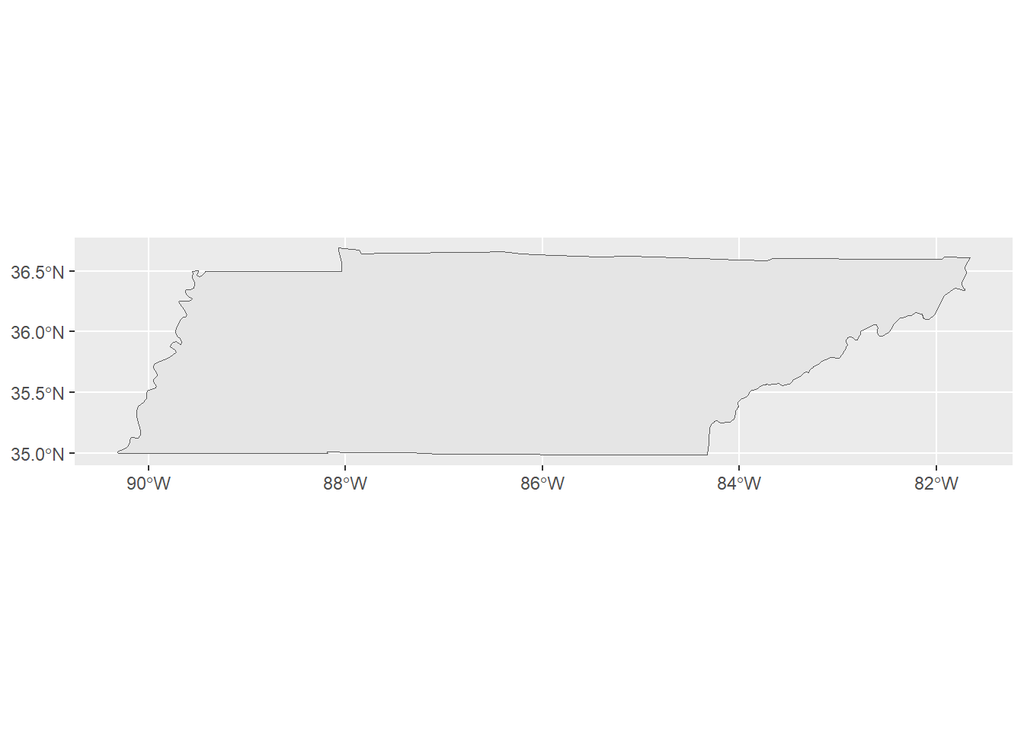

```r
tigris_use_cache = TRUE

# Load USA states map
usa <- ne_states(country = "united states of america", returnclass = "sf")

# Filter USA map to include only state of interest. You can edit Texas to anything you want
TN_BaseMap<- usa %>% filter(name %in% c("Tennessee"))

ggplot()+
  geom_sf(data = TN_BaseMap)
```

## Download property Shape file of interest and import it to R

```r
property_of_interest  <- st_read("C:/Users/ValentinaVaney/Documents/Oleander/Sweetgum_Stands_Tennessee.shp/Sweetgum_Stands_Tennessee.shp")
```

## Make sure both maps have the same projection

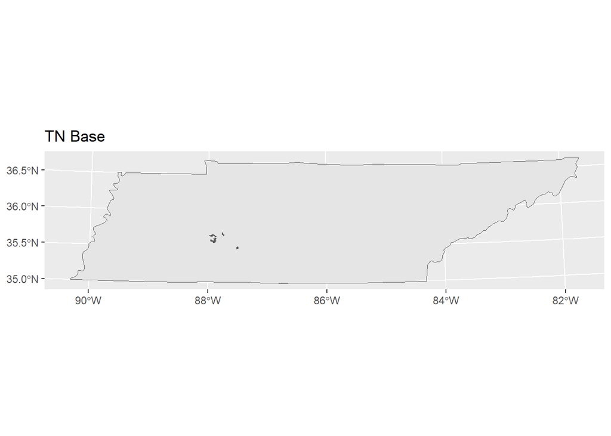

```r
utm_crs <- st_crs(32616)  #save it as a object for easy access

# Transform Texas_Louisiana_Map to the same CRS as hello_again
TN_BaseMap <- st_transform(TN_BaseMap, crs = utm_crs)

# Transform all stands to UTM CRS
property_of_interest <- st_transform(property_of_interest, utm_crs)

# Ensure the plot includes the property data
    # here I have inlcuded coordinates in coord_sf because property was too small to see without zooming in
 plotz <- ggplot() +
  geom_sf(data = TN_BaseMap) +
  geom_sf(data = property_of_interest, fill = "purple") +
  labs(title = "TN Base")

# Display the plot
print(plotz)
```

## Uploading websoil survey spatial data

1. IN the downloaded file of websoil survey data of your state there are 2 folders: spatial and tabular.
2. extract all spatial files from the spatial folder onto your R project and read in the shp. file

```r
tn_SSURGO_shp <- st_read("C:/Users/ValentinaVaney/Documents/Oleander/Tenessee/wss_gsmsoil_TN_[2016-10-13]/spatial/gsmsoilmu_a_tn.shp")
tn_SSURGO_shp <- st_transform(tn_SSURGO_shp,utm_crs)
```

# Spatial join between property shape file and SSURGO shape file

- here we are merging both shapefiles based on long and lat using st_intersectio(), so that we can get a corresponding mukey for area in property

```r
intersection_planar <- st_intersection(tn_SSURGO_shp, property_of_interest)
# you can ignore warning message
```

## Now that you have MUKEYS for every stand we can begin reading in the tabular data and extracting:

### *#cokey* , *compame* , *siteIndex*

## Begin by reading in tabular data

1. go to tabular folder from downloaded data from state
2. select comp table and read it in using the function freads
3. the data frame will not have any col names but luckily i wrote a query that will assign names to cols 😊
4. we will also download the cforprod table but will only use it later

```r
components <- fread("C:/Users/ValentinaVaney/Documents/Oleander/Tenessee/wss_gsmsoil_TN_[2016-10-13]/tabular./comp.txt")

#renaming cols so you don't have to 🐬
components <- components |>
  mutate(compact_r = V2, compname = V4,mukey = V108, cokey = V109) |>
  select(mukey,cokey,compact_r,compname) |>
  rename(MUKEY = mukey)



#dowloading c_forprod table for LATERRR

cforprod <- fread("C:/Users/ValentinaVaney/Documents/Oleander/Tenessee/wss_gsmsoil_TN_[2016-10-13]/tabular./cfprod.txt")
cforprod <- cforprod |>
  rename(plantsym = V1 , plantsciname = V2, plantcomname = V3, site_base = V4,site_i = V5,
         siteIndex = V6, site_2 = V7, fprod_1 = V8, fprod_2 = V9, f_prod_3 = V10, cokey = V11,cforprokey = V12)
```